# Least Squares as a Projection

Paul Schrimpf

2026-10-07

## Reading

- Required: **Song (2021) chapter 5** (which is the basis for these slides)
- Supplemental: Schrimpf (2018), Schrimpf (2013b), Schrimpf (2013a), Schrimpf (2013d), Schrimpf (2013c)

$$\def\Er{{\mathrm{E}}}
\def\cov{{\mathrm{Cov}}}
\def\var{{\mathrm{Var}}}
\def\R{{\mathbb{R}}}
\newcommand\norm[1]{\left\lVert#1\right\rVert}
\def\rank{{\mathrm{rank}}}$$

# Introduction

- Consider:
  $$y = X\beta + u$$
  - $y \in \R^n$
  - $X \in \R^{n \times k}$, nonstochastic
  - $\Er[u] = 0$, $\Er[uu'] = \sigma^2 I_n$
- $\hat{\beta} = (X'X)^{-1}X'y$ is linear in $y$ and unbiased
- If $\tilde{\beta}$ is another estimator linear in $y$ and unbiased, how does its variance compare to $\hat{\beta}$?

## Gauss-Markov Theorem

**Theorem: Gauss-Markov**

If $\Er[u] = 0$ and $\Er[uu'] = \sigma^2 I_n$, then the best linear unbiased estimator (BLUE) of $a'\beta = a'\hat{\beta}$ where $\hat{\beta} = (X'X)^{-1} X'y$

- This chapter: use linear algebra to further understand and generalize this result

# Projection Geometry and Quadratic Forms

## Linear Subspaces

- $V \subseteq \R^n$, **complete inner product space** (Hilbert space)
- $L \subset V$ a subspace

**Definition**

An $L \subset V$ is a **subspace** if $\forall x, y \in L$, $\alpha, \beta \in \R$, $\alpha x + \beta y \in L$

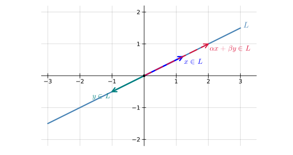

## Orthogonal Subspaces

**Definition**

Given a subspace $L \subset V$ **the orthogonal complement** of $L$ is
$$L^\perp = \{x \in V: x' l = 0 \,\forall l \in L\}$$

- For any $y \in V$, $\exists y_1 \in L$, $y_2 \in L^\perp$ s.t. $y = y_1 + y_2$

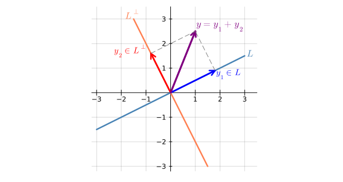

## Orthogonal and Sums of Subspaces

**Lemma 1.1**

Let $L_1$ and $L_2$ be subspaces of $V$, then
$$(\underbrace{L_1 + L_2}_{\{l_1 + l_2 \in V: l_1 \in L_2, l_2 \in L_2\}})^\perp = L_1^\perp \cap L_2^\perp$$
and
$$(L_1 \cap L_2)^\perp = L_1^\perp + L_2^\perp$$

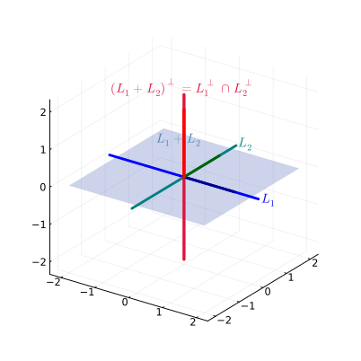

## Projection

**Definition**

$P_L y \in L$ is the **projection** of $y$ on $L$ if
$$\norm{y - P_L y } = \inf_{w \in L} \norm{y - w}$$

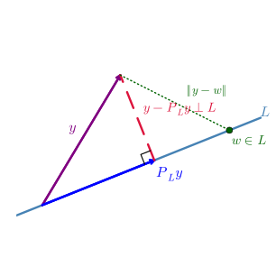

**Projection Theorem**

1. $P_L y$ exists, is unique, and is a linear function of $y$
2. For any $y_1^* \in L$, $y_1^* = P_L y$ iff $y- y_1^* \perp L$
- 2 implies if $y = y_1 + y_2$ with $y_1 \in L$ and $y_2 \in L^\perp$, then $y_1 = P_L y$

## Projection Map

**Theorem 1.2**

A linear map $G: V \to L$ is the projection map onto $L$ iff $Gy = y$ $\forall y \in L$ and $Gy = 0$ $\forall y \in L^\perp$

## Projection Map

**Definition**

Linear $G: V \to V$ is

- **idempotent** if $G (G y) = G y$ $\forall y \in V$
- **symmetric** if $G'y = G y$ $\forall y \in V$

**Theorem 1.3**

A linear map $G: V \to V$ is a projection map onto its range, $\mathcal{R}(G)$, iff $G$ is idempotent and symmetric.

## Projection Differences

**Theorem 1.4**

Let $L \subset V$ and $L_0 \subset L$ be subspaces. Then $P_L - P_{L_0} = P_{L \cap L_0^\perp}$

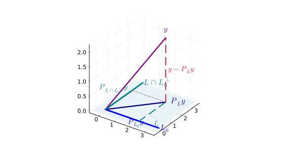

## Projection onto $X$

**Definition**

For linear $H: \R^s \to \R^r$, the **g-inverse** of $H$ is any $H^{-}$ s.t. $H H^{-} H = H$

**Theorem 1.5**

Let $X: \R^k \to \R^n$ be linear. The projection onto $\mathcal{R}(X)$ is $P_X = X(X'X)^- X'$ where $(X'X)^{-}$ is any g-inverse of $X'X$

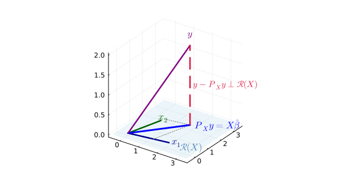

## Projection Spectrum

**Definition**

Let $A: V \to V$ be linear. Then $\lambda$ is an **eigenvalue** of $A$ and $v \neq 0$ is an associated **eigenvector** if $A v = \lambda v$

**Lemma 1.2**

The eigenvalues of a symmetric and idempotent matrix, $P$ are either $0$ or $1$. Furthmore rank of $P$ is the sum of its eigenvalues.

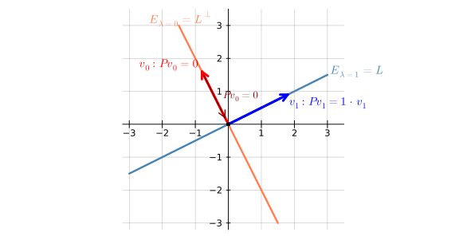

## Projection Rank

**Theorem 1.6**

1. $\mathrm{rank}(P_X) = \mathrm{rank}(X)$
2. $\rank(I-P_X) = n - \rank(X)$

# Generalized Linear Model

## Generalized Linear Model

$$Y = \theta + u$$

- $\theta \in L \subset \R^n$, $L$ a known subspace
- $u \in \R^n$ unobserved
- Example:
  $$Y_i = x_{i,1} \beta_1 + \cdots + x_{i,k} \beta_k + u_i$$
  - $X_k \equiv (x_{1,k}, ... , x_{n,k})'$, $X \equiv(X_1, ..., X_k)$, $\beta \equiv (\beta_1, ..., \beta_k)'$, $y \equiv (Y_1, ..., Y_n)'$, $u \equiv (u_1, ..., u_n)'$
    $$y= X\beta + u$$
    fits setup with $L = \mathcal{R}(X)$

## Least-Squares

- $\hat{\theta} = P_L y$, i.e. $\norm{y - \hat{\theta} y }^2 = \inf_{w \in L} \norm{y - w}^2$

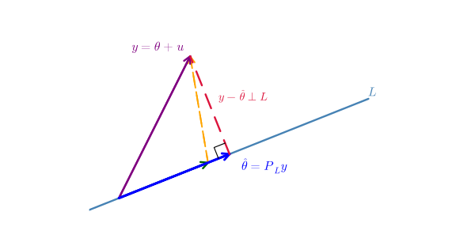

# Gauss-Markov Theorem

## Gauss-Markov Theorem

**Theorem: Gauss-Markov**

If $\Er[u] = 0$ and $\Er[uu'] = \sigma^2 I_n$, then the best linear unbiased estimator (BLUE) of $a'\theta = a'\hat{\theta}$ where $\hat{\theta} = P_L y$

**Corollary**

If
$$y = X'\beta + u$$
and $\Er[u] = 0$ and $\Er[uu'] = \sigma^2 I_n$, then the BLUE of $c'\beta$ is $c'\hat{\beta}$ with $\hat{\beta} = (X'X)^{-1} X' y$

# References

Schrimpf, Paul. 2013a. *Matrix Algebra and Introduction to Vector Spaces*. http://faculty.arts.ubc.ca/pschrimpf/526/lec03matrixAlgebra.pdf.

Schrimpf, Paul. 2013b. *Systems of Linear Equations*. http://faculty.arts.ubc.ca/pschrimpf/526/lec02systemsOfLinearEquations.pdf.

Schrimpf, Paul. 2013c. *Unconstrained Optimization (Especially Section 4 on Eigendecomposition)*. http://faculty.arts.ubc.ca/pschrimpf/526/lec10optimization.pdf.

Schrimpf, Paul. 2013d. *Vector Spaces*. http://faculty.arts.ubc.ca/pschrimpf/526/lec04vectorspaces.pdf.

Schrimpf, Paul. 2018. *Linearity*. http://faculty.arts.ubc.ca/pschrimpf/526/linear-526.pdf.

Song, Kyunchul. 2021. *Introduction to Econometrics*.